# Predicting IMDb Ratings Using Movie Characteristics

STAT 471/571/701, Fall 2017

Cheshta Dhingra

Due: April 30, 2017 at 11:59PM

# 1 I. Executive Summary

## 1.1 a. Background

Is it possible to predict the IMDb ratings for a movie before it even hits the theaters? What if we could use data like the movie’s title, director, cast, budget, etc. to predict it’s overall ratings? Given that thousands of movies are produced each year, I wanted to see if there was a better way to assess a movie without relying on critics or subjective human instincts.

## 1.2 b. Data

The data were obtained from the public dataset on kaggle.com, where a user scraped movie data from the IMDb website. It covers data 28 variables for 5043 movies, spanning across 100 years in 66 countries. There are 2399 unique director names, and thousands of actors/actresses. Below are the 28 variables:

“movie_title” “color” “num_critic_for_reviews” “movie_facebook_likes” “duration” “director_name” “director_facebook_likes” “actor_3_name” “actor_3_facebook_likes” “actor_2_name” “actor_2_facebook_likes” “actor_1_name” “actor_1_facebook_likes” “gross” “genres” “num_voted_users” “cast_total_facebook_likes” “facenumber_in_poster” “plot_keywords” “movie_imdb_link” “num_user_for_reviews” “language” “country” “content_rating” “budget” “title_year” “imdb_score” “aspect_ratio”

A more detailed summary of each variable can be found below in section IIA.

## 1.3 c. Methods

To develop my final model I created models using several different methods: backward selection, LASSO and Classification Trees. I then compared the testing errors for the different models and chose the one I felt had the most predictive power based on the ROC curves, AUC and significance of included variables. I then found the associated misclassification error using the given fact that the cost of mislabelling a high rated movie is 1.2x the cost of mislabelling a low-rated movie. This gave me my final Bayes Rule Classification Threshold. Finally, I tested my model on my subset of test data.

## 1.4 d. Main Findings

The key variables of importance were found to be: color + duration + director_facebook_likes + actor_3_facebook_likes + actor_1_facebook_likes + gross + num_voted_users + cast_total_facebook_likes + facenumber_in_poster + num_user_for_reviews + content_rating + title_year + actor_2_facebook_likes. The Bayes Rule Classification Threshold using the risk ratio of 1.2:1 was 0.454. This means that if the predicted probability of a high rating exceeds 0.454, we will predict that that movie gets a high rating. Using this, our misclassification error was about 26%.

## 1.5 e. Limitations

One issue is that I had to exclude several interesting variables such as language and country because my dataset was not a representative sample of movies made outside the US in foreign languages, but it may be very interesting to see how they compare to American films. The dataset also did not account for the difference in currencies in the variable for gross revenue, which means the interpretation of this variable is rather weak.

# 2 II. Data Analysis

## 2.1 a. Data Summary

### 2.1.1 Description of variables

The data consists of the following characteristics for each movie:

`movie_title` - title of the movie

`color` - whether the movie is in color or black and white

`num_critic_for_reviews` - number of critics who reviewed the movie

`movie_facebook_likes` - number of facebook likes the movie had

`duration` - length of the movie in minutes

`director_name` - name of the director

`director_facebook_likes` - number of facebook liked the director had

`actor_3_name` - name of the 3rd actor

`actor_3_facebook_likes` - number of facebook likes the 3rd actor had

`actor_2_name` - name of the 2nd actor

`actor_2_facebook_likes` - number of facebook likes the 2nd actor had

`actor_1_name` - name of the 1st actor

`actor_1_facebook_likes` - number of facebook likes the 1st actor had

`gross` - gross earnings

`genres` - genres that the movie falls under

`num_voted_users` - number of users who voted on the movie

`cast_total_facebook_likes` - total facebook likes for the entire cast

`facenumber_in_poster` - number of faces in the movie’s poster

`plot_keywords` - keywords regarding the movie’s plot

`movie_imdb_link` - link to the IMDb page

`num_user_for_reviews` - number of users who reviewed the movie

`language` - language the movie is in

`country` - country the movie was made in

`content_rating` - the content rating of the movie

`budget` - the total budget of the movie in its country’s currency

`title_year` - year the movie was made

`imdb_score` - the movie’s IMDb score

`aspect_ratio` - aspect ratio of the movie

### 2.1.2 Data cleaning

Since many of the values are missing, we will modify the dataset in the following ways:

1. `movie_name`, `director_name`, `actor_1_name`, `actor_2_name` and `actor_3_name`, `movie_imdb_link`, are not included since they have a large amount of variation and thus little predictive power.
2. `plot_keywords` will be removed for regression analysis but used later for text analysis.
3. `language` and `country` had very little variability so it was removed.
4. The rows with missing values in variables such as `num_critic_for_reviews`, `duration`, `director_facebook_likes`, `actor_3_facebook_likes`, `actor_2_facebook_likes`, `actor_1_facebook_likes`, `gross`, `facenumber_in_poster`, `aspect_ratio`, `title_year`, have been excluded.
5. The event of interest is `imdb_score`. I have coded a binary variable for movies that recieved a rating above and below 6 as `imdb_binary`.

### 2.1.3 Graphical Summary

In the Appendix is a graphical summary of the 19 input variables and the response variable we retained in the dataset `movies`.

## 2.2 b. Analyses

### 2.2.1 Creating a Test set

I retained 20% of the data (about 800 observations) as a testing set to assess my final model. This leaves about 3,200 observations to train the model.

### 2.2.2 Backward Selection

The first method I will use is Backward Selection. Starting with the full model I successively remove the variable with the highest p-value (lowest significance), then run the logistic regression with the remaining variables. This process is repeated until I reach a model which has only variables significant at the 0.05 level. The best model is shown below with its associated Anova test results (`fit.best`).

Here is the ANOVA test for our final backward selection model:

```
## Analysis of Deviance Table (Type II tests)
##
## Response: imdb_binary
##                           LR Chisq Df Pr(>Chisq)
## color                         9.56  1  0.0019834 **
## duration                    168.21  1  < 2.2e-16 ***
## director_facebook_likes       8.24  1  0.0041025 **
## actor_3_facebook_likes       11.64  1  0.0006451 ***
## actor_1_facebook_likes       23.24  1  1.433e-06 ***
## gross                        44.27  1  2.863e-11 ***
## num_voted_users             360.01  1  < 2.2e-16 ***
## cast_total_facebook_likes    23.80  1  1.069e-06 ***
## facenumber_in_poster         12.77  1  0.0003516 ***
## num_user_for_reviews         90.18  1  < 2.2e-16 ***
## content_rating               73.26 12  7.819e-11 ***
## title_year                    5.52  1  0.0188334 *
## actor_2_facebook_likes       24.12  1  9.046e-07 ***
## ---
## Signif. codes:  0 '***' 0.001 '**' 0.01 '*' 0.05 '.' 0.1 ' ' 1
```

### 2.2.3 LASSO in classifications:

Next, I will use LASSO to find the best model variables. The regularization techniques used in regression are readily applied to classification problems. For a given lambda we minimize -log liklihood/n + lambda |beta| To remain consistent in both binary and continuous responses, glmnet() uses the following penalized least squares. RSS/(2n) + lambda |beta|

Shown below is the plot of the binomial deviance from the 10-fold cross validated LASSO model. We want to minimize this.

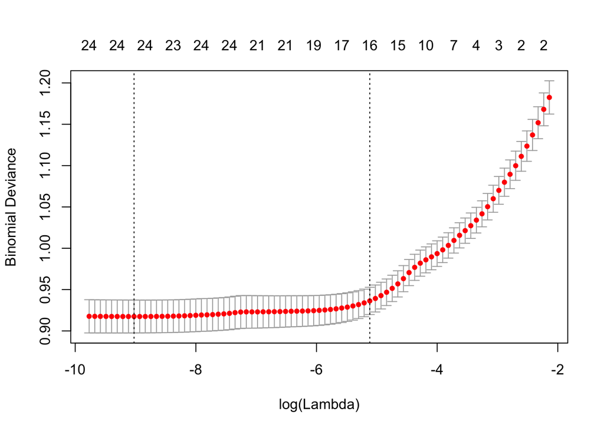

```
## Analysis of Deviance Table (Type II tests)
##
## Response: imdb_binary
##                           LR Chisq Df Pr(>Chisq)
## color                         9.56  1  0.0019834 **
## duration                    168.21  1  < 2.2e-16 ***
## director_facebook_likes       8.24  1  0.0041025 **
## actor_3_facebook_likes       11.64  1  0.0006451 ***
## actor_1_facebook_likes       23.24  1  1.433e-06 ***
## gross                        44.27  1  2.863e-11 ***
## num_voted_users             360.01  1  < 2.2e-16 ***
## cast_total_facebook_likes    23.80  1  1.069e-06 ***
## facenumber_in_poster         12.77  1  0.0003516 ***
## num_user_for_reviews         90.18  1  < 2.2e-16 ***
## content_rating               73.26 12  7.819e-11 ***
## title_year                    5.52  1  0.0188334 *
## actor_2_facebook_likes       24.12  1  9.046e-07 ***
## ---
## Signif. codes:  0 '***' 0.001 '**' 0.01 '*' 0.05 '.' 0.1 ' ' 1
```

```
## Analysis of Deviance Table (Type II tests)
##
## Response: imdb_binary
##                         LR Chisq Df Pr(>Chisq)
## color                      10.02  1  0.0015446 **
## duration                  166.50  1  < 2.2e-16 ***
## director_facebook_likes     8.76  1  0.0030751 **
## actor_3_facebook_likes      6.05  1  0.0139048 *
## gross                      58.30  1  2.250e-14 ***
## num_voted_users           368.97  1  < 2.2e-16 ***
## facenumber_in_poster       14.74  1  0.0001232 ***
## num_user_for_reviews       87.30  1  < 2.2e-16 ***
## content_rating             79.26 12  5.714e-12 ***
## title_year                  5.20  1  0.0225319 *
## ---
## Signif. codes:  0 '***' 0.001 '**' 0.01 '*' 0.05 '.' 0.1 ' ' 1
```

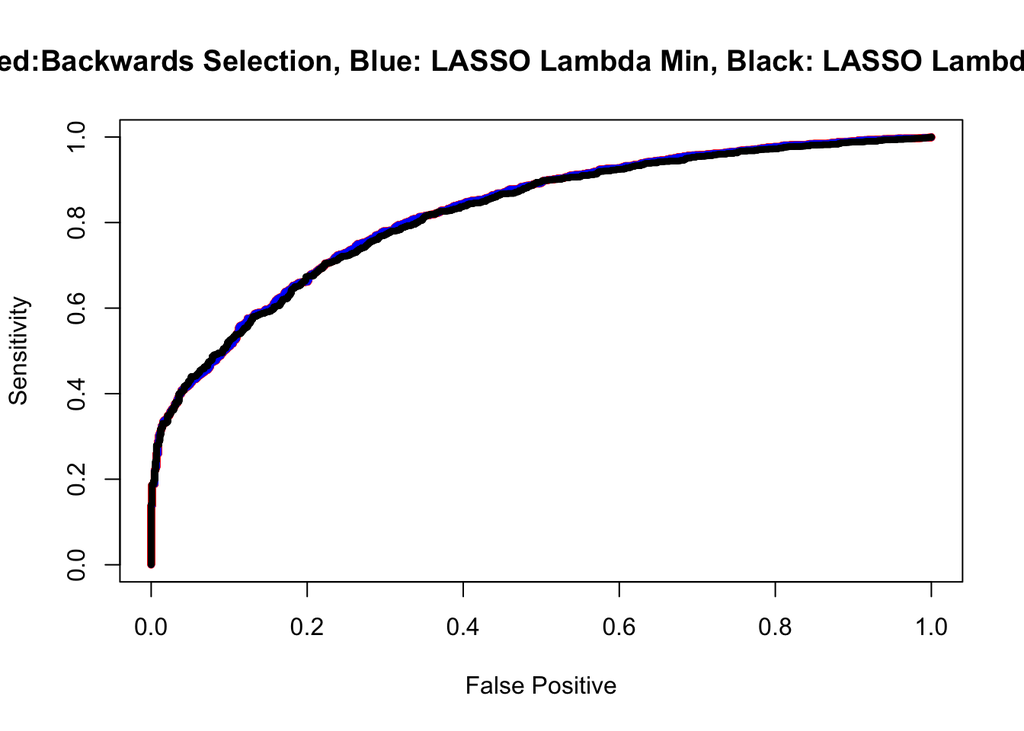

```
## Area under the curve: 0.8219
```

```
## Area under the curve: 0.8219
```

```
## Area under the curve: 0.8184
```

Now that we have selected our final model of imdb_binary~color + duration + director_facebook_likes + actor_3_facebook_likes + actor_1_facebook_likes + gross + num_voted_users + cast_total_facebook_likes + facenumber_in_poster + num_user_for_reviews + content_rating + title_year + actor_2_facebook_likes

which was obtained through backward selection, we now need to come up with a reasonable classifier for our model. Based on a quick and somewhat arbitrary guess, it’s estimated that it costs a bit more to mislabel a high-rated movie as it does to mislabel a low-rated movie. Based on this risk ratio of 1:1.2, I will propose a specific classification rule to minimize the cost. Then:

$a_{10}/a_{01}=1.2$ –> $a_{01}/a_{10}=0.833$

$P(Y=1|x) > \frac{a_{01}/a_{10}}{1+a_{01}/a_{10}} = \frac{0.833}{1+0.833}= 0.4544$

$logit > log(\frac{0.4544}{1 - 0.4544}) = log(0.8328) = -0.183$ gives us the Bayes rule!

Therefore the Bayes Rule Classification Threshold using this risk ratio would be about 0.45. Using this threshold we get a weighted misclassification error (MCE) of 0.26.

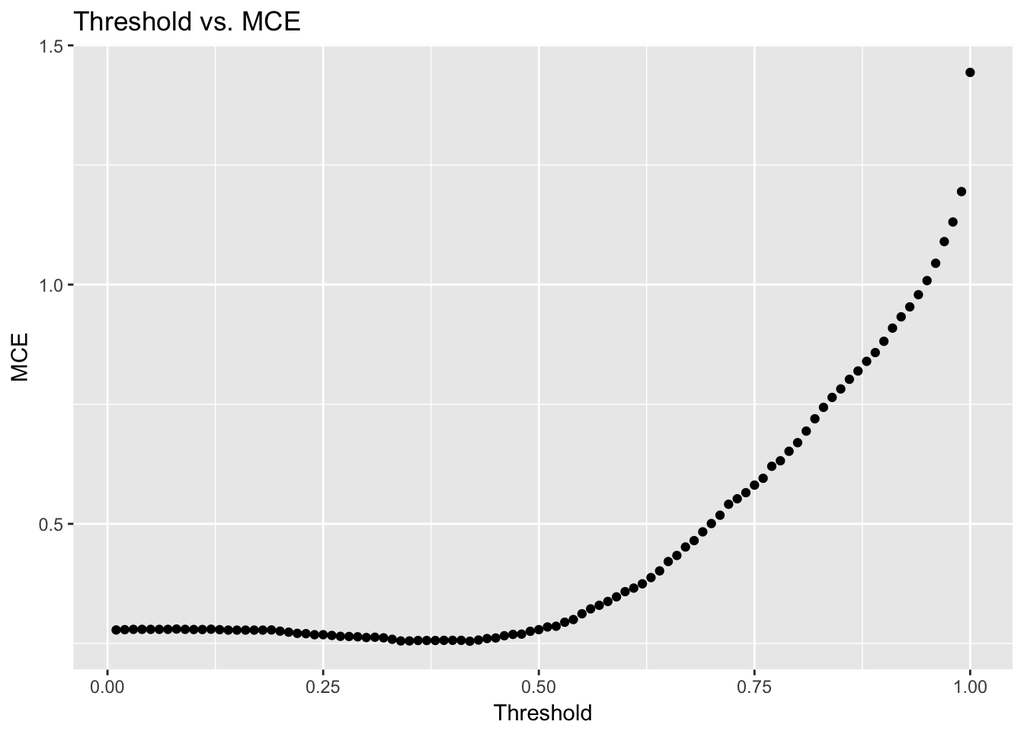

### 2.2.4 Classification trees

#### 2.2.4.1 Single Tree

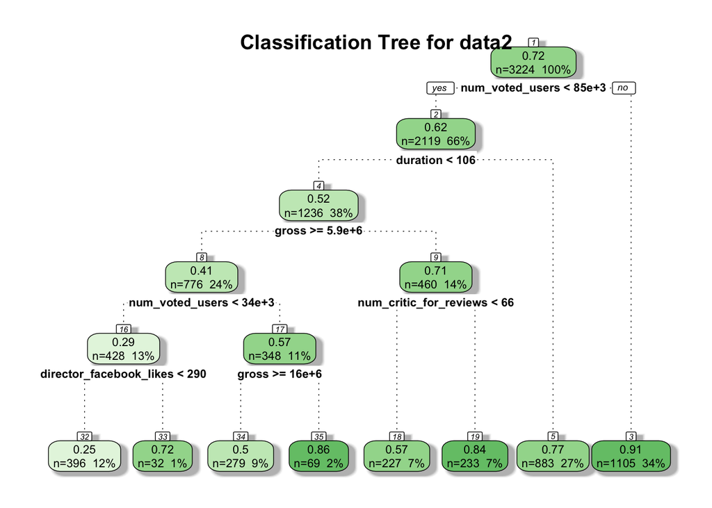

```
##         1         8        11        20        27        29        30
## 0.9076923 0.9076923 0.9076923 0.9076923 0.9076923 0.9076923 0.9076923
##        46        49        50        56        57        60        66
## 0.9076923 0.9076923 0.9076923 0.4982079 0.9076923 0.9076923 0.9076923
##        70        72        82        86       101       102
## 0.9076923 0.9076923 0.9076923 0.9076923 0.9076923 0.9076923
```

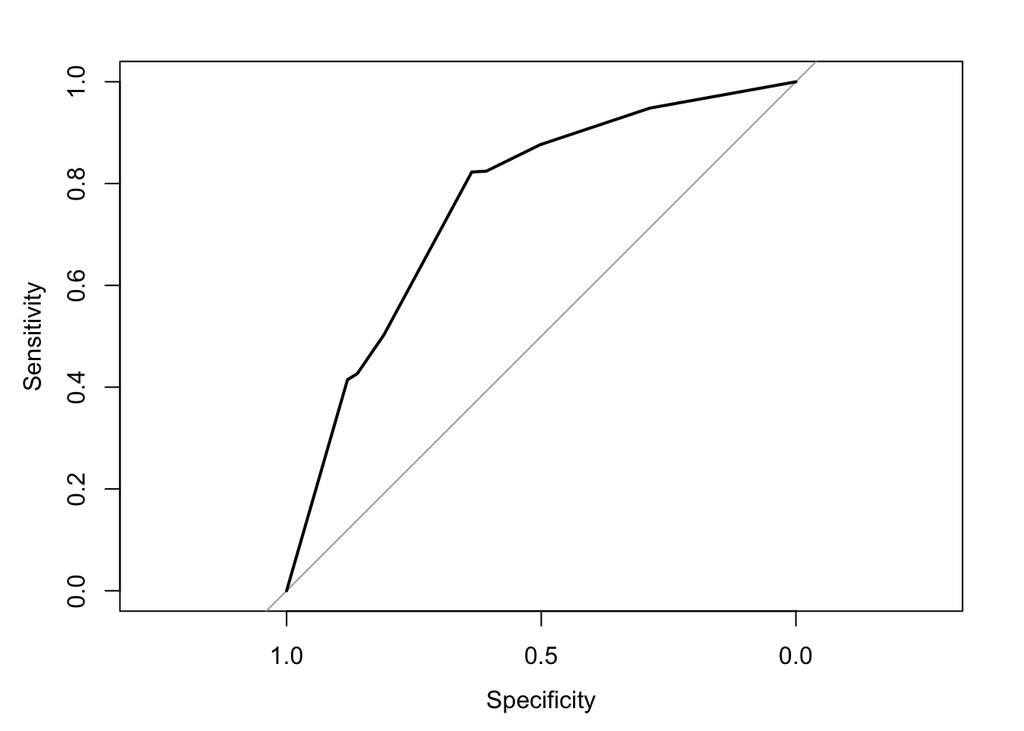

```
##
## Call:
## roc.default(response = test$imdb_binary, predictor = prob.1,     plot = T)
##
## Data: prob.1 in 209 controls (test$imdb_binary 0) < 598 cases (test$imdb_binary 1).
## Area under the curve: 0.7607
```

### 2.2.5 Evaluating my model using testing data

As we can see, the backward model still has the highest AUC. I will use this model to get the fitted prob’s using the testing data:

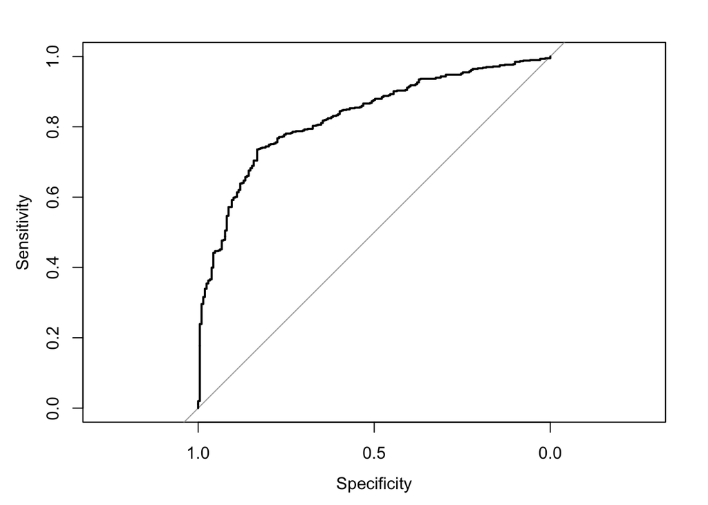

```
## Area under the curve: 0.8278
```

## 2.3 c. Conclusion

The key variables of importance were found to be: color + duration + director_facebook_likes + actor_3_facebook_likes + actor_1_facebook_likes + gross + num_voted_users + cast_total_facebook_likes + facenumber_in_poster + num_user_for_reviews + content_rating + title_year + actor_2_facebook_likes. The Bayes Rule Classification Threshold using the risk ratio of 1.2:1 was 0.454. This means that if the predicted probability of a high rating exceeds 0.454, we will predict that that movie gets a high rating. Using this, our misclassification error was about 26%.

# 3 III. Citation

Data obtained from: (https://www.kaggle.com/deepmatrix/imdb-5000-movie-dataset)

# 4 IV. Appendix

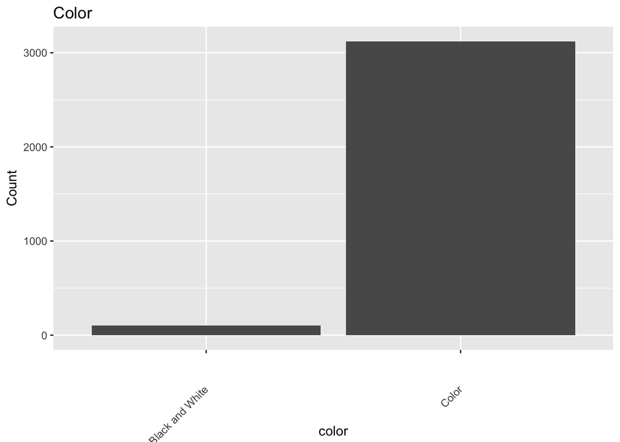

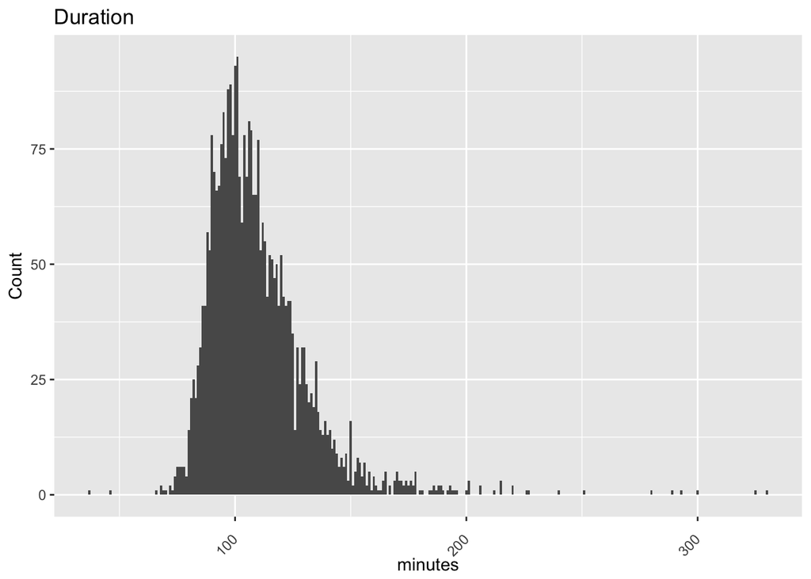

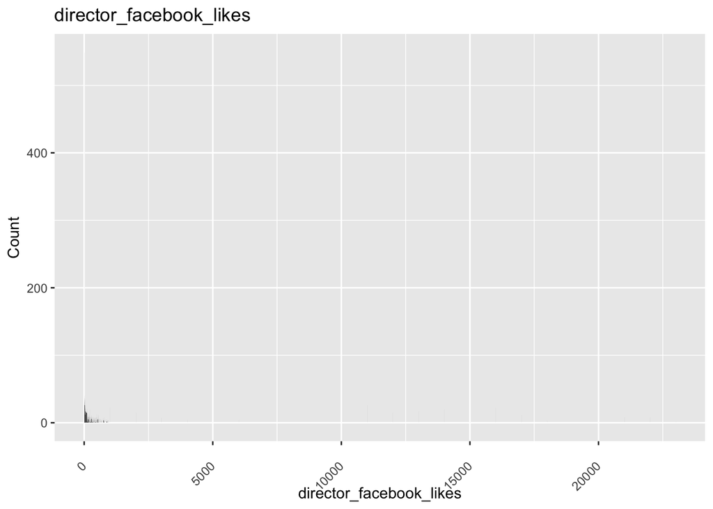

[figure not shown]

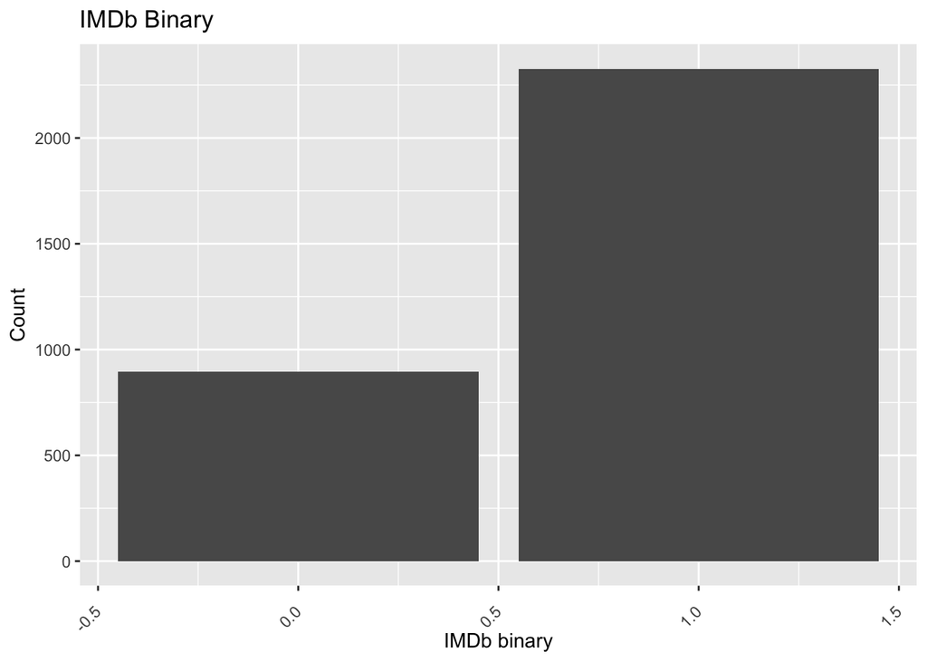